# exploratory data analysis project - campaign finance

Hannah Gorman

January 22, 2018

## Introduction

In this project for the Udacity data analysis nanodegree, I’m going to explore the influence of campaign contributions on 2014 congressional election outcomes. The data on campaign contributions is from the federal elections commission.

I will use three primary measures of campaign finance: dollars per campaign, average campaign contribution size, and % of opponent spend.

Along with win/loss, I will look at vote share as a continuous outcome variable. I will cut the data by candidate party (dem/rep/ind), state, and contributor type (PAC vs. individual) to see if trends in the impact of campaign finance vary based on these election attributes.

### Tasks

- Asses & clean finance data [Jupyter notebook] √
- Gather, asses & clean outcome data [Jupyter notebook] √
- Read in and convert dataset to tidy format √
- Visualize wins and losses √
  - histogram of voteshare colored by dem/rep/ind √ ** facetwrap by campaign type √ ** facetwrap by state √
- Visualize $ contributed
  - histogram of dollars/campaign colored by dem/rep/ind
  - boxplot of dollars/campaign by state
- Visualize dollars contributed by win/loss
  - scatterplot of vote share vs. dollars ** add win/loss line ** color dem/rep/ind ** facetwrap by state
  - scatterplot of vote share vs. average contribution size
    - add win/loss line
    - color dem/rep/ind
    - facetwrap by state
    - facetwrap by contributor type

## Read In and Data Preparation

```
## 'data.frame':    40185 obs. of  12 variables:
##  $ COMMITTEE_ID      : Factor w/ 2696 levels "C00000059","C00000422",..: 1748 143 239 1473 151 1674 300 610 549 574 ...
##  $ TRANSACTION_AMOUNT: int  1000 5000 2500 1000 2500 3 2600 1000 1000 1000 ...
##  $ CAND_ID           : Factor w/ 392 levels "H0AL02087","H0AL05163",..: 120 120 120 120 120 120 120 120 120 120 ...
##  $ PAC_NAME          : Factor w/ 3265 levels "10TH CONGRESSIONAL DIST DEMOCRATIC COMMITTEE",..: 1078 1078 1078 1078 1078 397 1078 1078 1078 1078 ...
##  $ TRANSACTION_DATE  : Factor w/ 609 levels "","2012-10-02",..: 52 75 135 106 152 121 254 260 249 250 ...
##  $ CAND_NAME         : Factor w/ 392 levels "ADAMS, ALMA SHEALEY",..: 157 157 157 157 157 157 157 157 157 157 ...
##  $ CAND_ELECTION_YEAR: Factor w/ 1 level "2014-01-01": 1 1 1 1 1 1 1 1 1 1 ...
##  $ CAND_PARTY        : Factor w/ 4 levels "DEM","IND","LIB",..: 4 4 4 4 4 4 4 4 4 4 ...
##  $ CAND_STATE        : Factor w/ 53 levels "AK","AL","AR",..: 46 46 46 46 46 46 46 46 46 46 ...
##  $ CAND_DISTRICT     : int  5 5 5 5 5 5 5 5 5 5 ...
##  $ CAND_RACE_STATUS  : Factor w/ 3 levels "C","I","O": 2 2 2 2 2 2 2 2 2 2 ...
##  $ CAND_OFFICE       : Factor w/ 2 levels "H","S": 1 1 1 1 1 1 1 1 1 1 ...
```

```
## 'data.frame':    1343 obs. of  4 variables:
##  $ CAND_ID  : Factor w/ 1343 levels "H0AL02087","H0AL05163",..: 1 2 3 4 5 6 7 8 9 10 ...
##  $ VOTECOUNT: num  113103 115338 133687 124139 151630 ...
##  $ VOTESHARE: num  67.3 74.4 98.4 63.2 79.4 ...
##  $ WIN_LOSS : int  1 1 1 1 1 0 1 0 0 1 ...
```

The two datasets overlap for `265` candidates.

```
## # A tibble: 6 x 15
## # Groups:   CAND_ID, CAND_NAME, CAND_PARTY, CAND_STATE, CAND_DISTRICT [6]
##     CAND_ID           CAND_NAME CAND_PARTY CAND_STATE CAND_DISTRICT
##       <chr>              <fctr>     <fctr>     <fctr>         <int>
## 1 S6LA00227    LANDRIEU, MARY L        DEM         DC             0
## 2 S8CO00172       UDALL, MARK E        DEM         CO             0
## 3 S8KS00227 ORMAN, GREGORY JOHN        IND         KS             0
## 4 S8MS00055       COCHRAN, THAD        REP         MS             0
## 5 S8NC00239        HAGAN, KAY R        DEM         NC             0
## 6 S8NM00184          UDALL, TOM        DEM         NM             0
## # ... with 10 more variables: CAND_RACE_STATUS <fctr>,
## #   TOTAL_CONTRIBUTIONS <int>, MEAN_CONTRIBUTION_AMOUNT <dbl>,
## #   FIRST_CONTRIBUTION <date>, NUMBER_OF_CONTRIBUTIONS <int>,
## #   VOTECOUNT <dbl>, VOTESHARE <dbl>, WIN_LOSS <int>,
## #   STATE_DISTRICT <chr>, CHAMBER <chr>
```

## Wins and Losses by Party

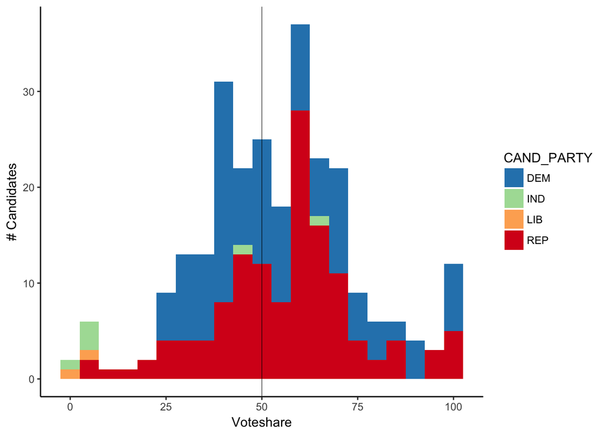

Let’s break this out by candidate status: challenger (C), incumbent (I), or open race (O)

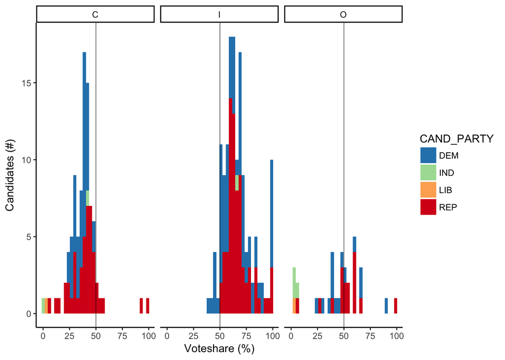

Let’s also break things out by state in cases where a state has a significant number of races, e.g. 10 or more.

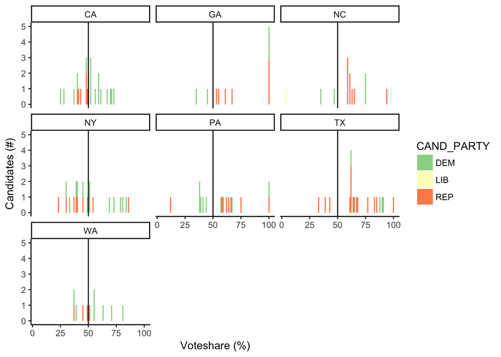

From this initial visualization, I notice that our dataset is a little unbalanced. The dataset includes slightly more data on winning candidates (>50% of voteshare) than on losing candidates (<50% of voteshare). This is likely due to the fact that campaign contribution data was incomplete. Candidates in the outcomes dataset with verysmall (<1%) voteshare were also frequently bundled into the category “Scattered.” This biases both datasets somewhat towards winning candidates; we can also see this impact in a boxplot, or when we table our data by chamber and win/loss:

```
##
##       0   1
##   H  97 147
##   S   9  12
```

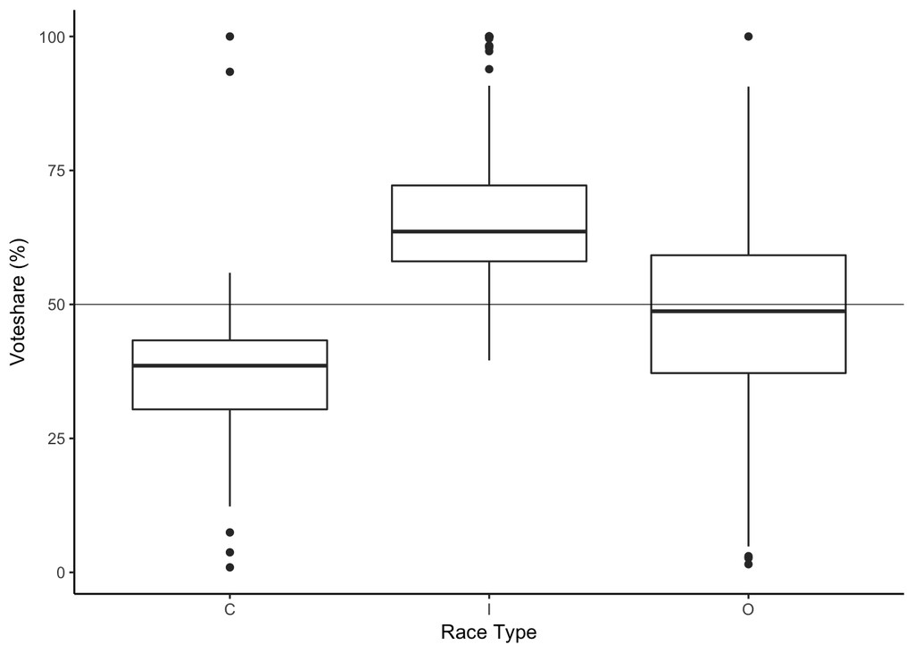

The limitation of missing candidates means that this dataset may not be ideal for causal questions–i.e., predicting what causes a candidate to win or lose. The approximately normal distribution we see in the above histogram is most likely due to the data we’ve chosen. If we had data on more candidates per race, we would likely see much more skewed data, with most candidates falling below 50% voteshare.

Even given this limitation however, we can find some interesting patterns. The candidate status breakout shows us that the mean voteshare for challengers is much lower than that for incumbents, while open races (the least common type) have a center of about 50%. We can examine this trend further by coloring our histogram by win/loss instead of party, since in a race with more than 2 candidates, a voteshare of less than 50% may be sufficient to win:

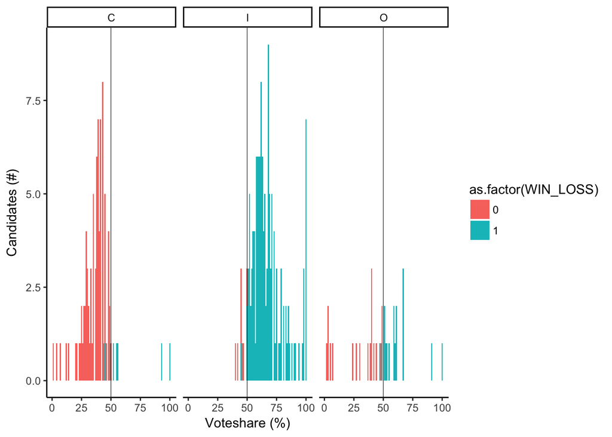

As this histogram shows, winning candidates were almost all incumbents and losing candidates were almost all challengers. Given the strength of this covariance in this dataset, it may actually be more interesting to examine differences between incumbents and challengers rather than winners and losers. The contribution dataset can shed light on the material differences between these types of candidates.

This prompts some questions:

- Do incumbents receive larger contributions, or more contributions, or contributions earlier in the cycle due to their name recognition?
- Within the group of winning incumbents, do factors like state, party, and chamber have an impact on candidates’ voteshare? *E.g., do incumbent republicans win by more than incumbent democrats? Vis versa?*
- What outliers do we see–incumbents who lost, or challengers who won? Can we learn more about these candidates’ circumstances or strategies?

## Incumbents vs. Challengers

### Contribution Patterns

#### Do incumbents receive larger contributions?

A first intuition about the differences between incumbents and challengers is that incumbents raise significantly more overall than challengers. We can start by looking at patterns in the sum of all contributions in the campaign finance dataset:

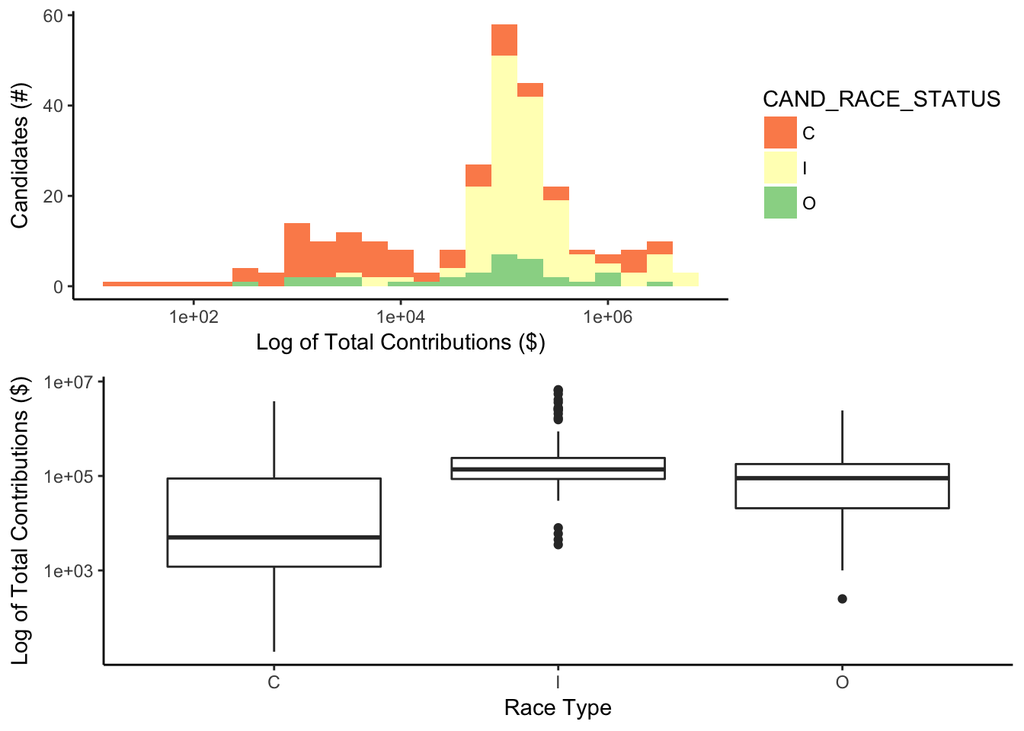

Interestingly, the median contribution for open races is closer to that of incumbents. This suggests that it might not just be that incumbents have an edge in fundraising, but that they specifically deter people from giving to challengers.

This could also be an effect of districts that consistently favor a certain party, since most commonly a challenger is from a different party than the incumbent.

We can also check out the size of the **mean** contribution candidates received. This may shed light on what kinds of donors lead to this big fundraising advantage for incumbents:

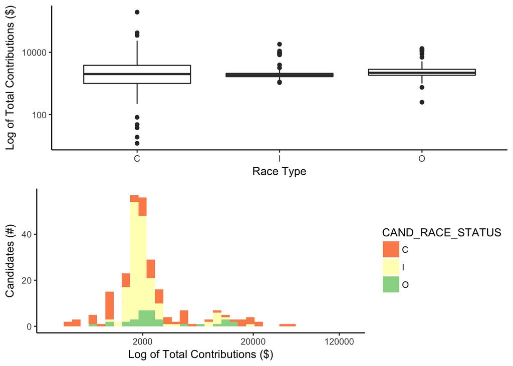

These plots show us that the type of race a candidate runs doesn’t seem to determine how big their average campaign contribution is. This may have to do with the underlying data: while cleaning the campaign finance dataset, I observed that entities frequently ‘batched’ many small contributions (e.g., 40 contributions of 500 dollars each instead of giving 20k). We can manipulate the original finance dataset in order to compare:

```
## # A tibble: 6 x 4
## # Groups:   CAND_ID, CAND_RACE_STATUS [1]
##     CAND_ID CAND_RACE_STATUS COMMITTEE_ID COMMITTEE_TOTAL_CONTRIBUTIONS
##      <fctr>           <fctr>       <fctr>                         <int>
## 1 H0AL02087                I    C00000901                          5000
## 2 H0AL02087                I    C00002972                          3500
## 3 H0AL02087                I    C00005249                          5000
## 4 H0AL02087                I    C00014555                          1000
## 5 H0AL02087                I    C00030718                          3000
## 6 H0AL02087                I    C00035683                          5000
```

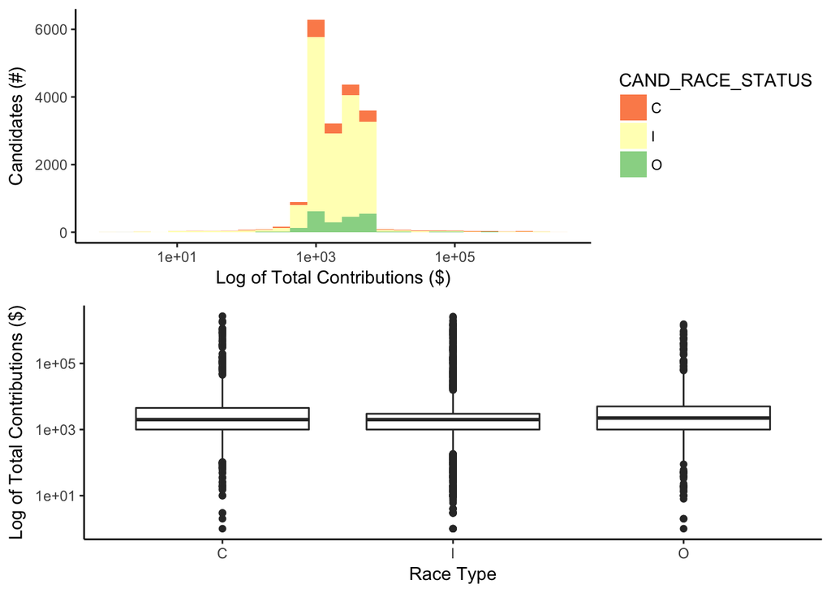

Looking at the underlying finance data confirms that while there are many *more* transactions from PACs to incumbents than open race candidates and especially than challengers, how much they give a candidate whom they do support does not vary based on incumbency.

Since the number rather than the size of contributions seems to matter (if anything), I should further quantify the difference in the **number of contributions** a candidate receives based on incumbancy status.

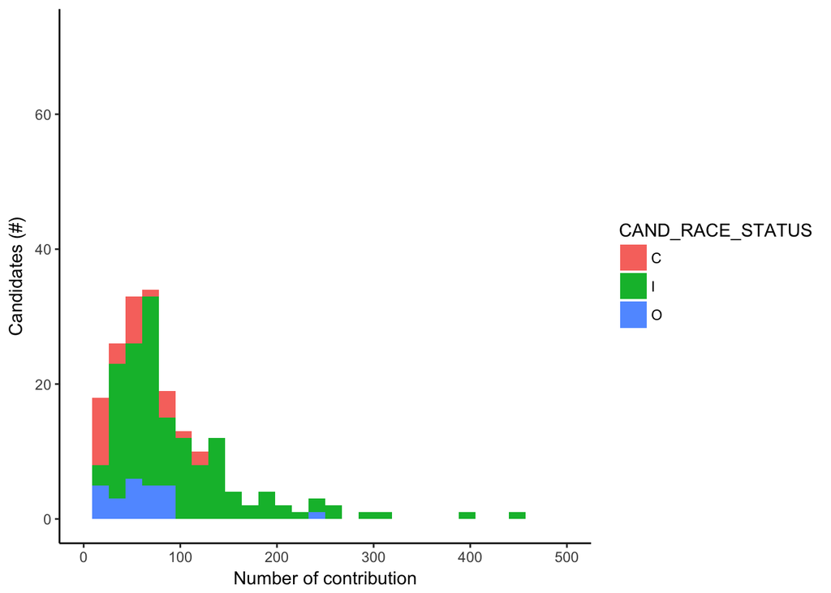

```
## df$CAND_RACE_STATUS: C
##    Min. 1st Qu.  Median    Mean 3rd Qu.    Max.
##    1.00    1.00    3.00   34.88   22.00  861.00
## --------------------------------------------------------
## df$CAND_RACE_STATUS: I
##    Min. 1st Qu.  Median    Mean 3rd Qu.    Max.
##    2.00   51.25   73.00  164.01  131.50 6043.00
## --------------------------------------------------------
## df$CAND_RACE_STATUS: O
##    Min. 1st Qu.  Median    Mean 3rd Qu.    Max.
##    1.00    8.25   43.50   45.97   69.50  236.00
```

The histogram and summary of contributions by race type suggest that an incumbent gets 5 times as many contributions as a challenger and 3-4 times as many times as a candidate in an open race.

#### Do incumbents receive contributions earlier in the cycle?

Another possible source of incumbent advantage may be that funders identify the candidate earlier in the race than a challenger. If this is the case, it could impact challenger fundraising strategies.

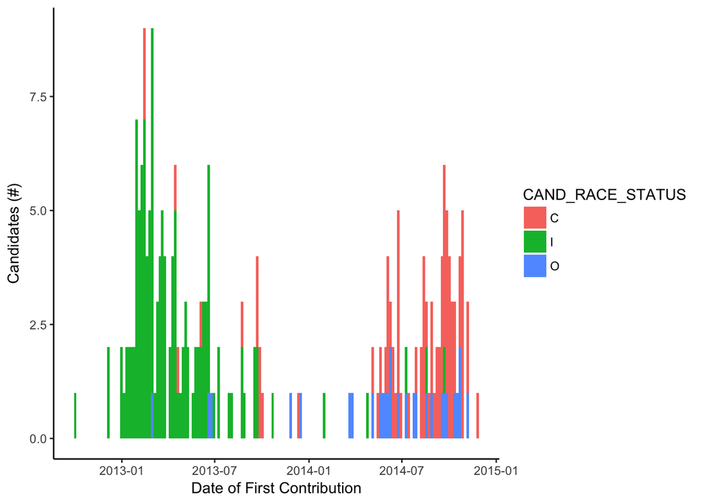

This plot of first contribution date sheds a really interesting ligth on the disparity between incumbent and challenger fundraising. It shows either that incumbents may get more contributions simply because they start earlier, or that an incumbents’ greater name recognition may give them an edge in fundraising years in advance.

It’s also possible that money spent earlier in a campaign is more effective–it’s likely that it pays off to reach voters before your competitor.